# Assignment 2: Practice of Class Codes (R for Data Science)

Manzi Joel (Student ID: 20252MBI024)

2026-10-31

Practice of the codes shared by the lecturer: https://rpubs.com/Mapara_lee/1434996. Part B practises the ggplot2 `geom_*()` functions given in class.

# Part A: Class codes

## 1. R as a calculator

```r
5 + 3; 10 / 4; 2^5; sqrt(81); log(100, base = 10)
```

```
## [1] 8
```

```
## [1] 2.5
```

```
## [1] 32
```

```
## [1] 9
```

```
## [1] 2
```

## 2. Data structures

### Vectors

```r
age <- c(20, 35, 32, 29)
summary(age)
```

```
##    Min. 1st Qu.  Median    Mean 3rd Qu.    Max.
##   20.00   26.75   30.50   29.00   32.75   35.00
```

```r
age <- c(35, 24, 18, 24)
mean(age)
```

```
## [1] 25.25
```

```r
x <- c(TRUE, FALSE)          # logical
class_g <- c("M", "F", "F", "M") # character
x <- 9:29                    # integer
x <- c(1 + 0i, 2 + 4i)       # complex
class(x)
```

```
## [1] "complex"
```

### Matrix

```r
(x <- matrix(1:6, nrow = 2, ncol = 3))
```

```
##      [,1] [,2] [,3]
## [1,]    1    3    5
## [2,]    2    4    6
```

```r
(y <- matrix(1:6, nrow = 3, ncol = 2))
```

```
##      [,1] [,2]
## [1,]    1    4
## [2,]    2    5
## [3,]    3    6
```

```r
x %*% y
```

```
##      [,1] [,2]
## [1,]   22   49
## [2,]   28   64
```

### List and factor

```r
(x <- list(1, "a", TRUE, 1 + 4i))
```

```
## [[1]]
## [1] 1
##
## [[2]]
## [1] "a"
##
## [[3]]
## [1] TRUE
##
## [[4]]
## [1] 1+4i
```

```r
x <- factor(c("yes", "yes", "no", "yes", "no"))
table(x)
```

```
## x
##  no yes
##   2   3
```

### Missing values

```r
x <- c(1, 2, NA, 10, 3)
is.na(x)
```

```
## [1] FALSE FALSE  TRUE FALSE FALSE
```

```r
x <- c(1, 2, NA, 4, NA, 5)
y <- c("a", "b", NA, "d", NA, "f")
good <- complete.cases(x, y)
x[good]; y[good]
```

```
## [1] 1 2 4 5
```

```
## [1] "a" "b" "d" "f"
```

### Coercion

```r
sum(c(TRUE, TRUE, FALSE, FALSE, FALSE))
```

```
## [1] 2
```

```r
class(c(1, "a", TRUE))
```

```
## [1] "character"
```

## 3. Data frame

```r
studentID  <- c(1, 2, 3, 4, 5)
math_score <- c(12, 17, 10, 9, NA)
gender     <- c("M", "F", "M", "M", "F")
it_score   <- c(13, 18, 11, 10, 19)
scoredata  <- data.frame(studentID, gender, math_score, it_score)
scoredata
```

```
##   studentID gender math_score it_score
## 1         1      M         12       13
## 2         2      F         17       18
## 3         3      M         10       11
## 4         4      M          9       10
## 5         5      F         NA       19
```

Data from keyboard (works only in interactive RStudio):

```r
data_class2 <- data.frame(height = numeric(0), weight = numeric(0), bmi = numeric(0))
data_class2 <- edit(data_class2)
```

## 4. Data import and built-in data

```r
data_class <- read.table("data/class_data.txt", header = TRUE)
variable.names(data_class)
```

```
## [1] "HEIGHT" "WEIGHT"
```

```r
head(data_class)
```

```
##   HEIGHT WEIGHT
## 1    161     50
## 2    155     49
## 3    158     42
## 4    170     65
## 5    160     60
## 6    156     52
```

```r
tail(data_class)
```

```
##    HEIGHT WEIGHT
## 38    164     47
## 39    163     52
## 40    168     55
## 41    157     48
## 42    164     58
## 43    154     55
```

```r
data_class[10:20, ]
```

```
##    HEIGHT WEIGHT
## 10    167     51
## 11    160     60
## 12    155     42
## 13    154     53
## 14    155     48
## 15    157     48
## 16    157     48
## 17    160     53
## 18    158     52
## 19    160     51
## 20    160     53
```

```r
summary(data_class$WEIGHT)
```

```
##    Min. 1st Qu.  Median    Mean 3rd Qu.    Max.
##   42.00   48.00   52.00   52.47   56.00   65.00
```

```r
length(data_class$WEIGHT)
```

```
## [1] 43
```

```r
data("airquality")
str(airquality)
```

```
## 'data.frame':    153 obs. of  6 variables:
##  $ Ozone  : int  41 36 12 18 NA 28 23 19 8 NA ...
##  $ Solar.R: int  190 118 149 313 NA NA 299 99 19 194 ...
##  $ Wind   : num  7.4 8 12.6 11.5 14.3 14.9 8.6 13.8 20.1 8.6 ...
##  $ Temp   : int  67 72 74 62 56 66 65 59 61 69 ...
##  $ Month  : int  5 5 5 5 5 5 5 5 5 5 ...
##  $ Day    : int  1 2 3 4 5 6 7 8 9 10 ...
```

## 5. Exploratory data analysis

```r
summary(data_class)
```

```
##      HEIGHT          WEIGHT
##  Min.   :150.0   Min.   :42.00
##  1st Qu.:156.0   1st Qu.:48.00
##  Median :159.0   Median :52.00
##  Mean   :159.3   Mean   :52.47
##  3rd Qu.:162.0   3rd Qu.:56.00
##  Max.   :170.0   Max.   :65.00
```

```r
apply(data_class, 2, sd)
```

```
##   HEIGHT   WEIGHT
## 4.304444 5.750150
```

```r
c(Mean = mean(data_class$HEIGHT), SD = sd(data_class$HEIGHT))
```

```
##       Mean         SD
## 159.255814   4.304444
```

```r
c(Mean = mean(data_class$WEIGHT), SD = sd(data_class$WEIGHT))
```

```
##     Mean       SD
## 52.46512  5.75015
```

### Categorical vs continuous (iris)

```r
by(iris$Petal.Length, iris$Species, mean)
```

```
## iris$Species: setosa
## [1] 1.462
## ------------------------------------------------------------
## iris$Species: versicolor
## [1] 4.26
## ------------------------------------------------------------
## iris$Species: virginica
## [1] 5.552
```

```r
by(iris$Petal.Length, iris$Species, summary)
```

```
## iris$Species: setosa
##    Min. 1st Qu.  Median    Mean 3rd Qu.    Max.
##   1.000   1.400   1.500   1.462   1.575   1.900
## ------------------------------------------------------------
## iris$Species: versicolor
##    Min. 1st Qu.  Median    Mean 3rd Qu.    Max.
##    3.00    4.00    4.35    4.26    4.60    5.10
## ------------------------------------------------------------
## iris$Species: virginica
##    Min. 1st Qu.  Median    Mean 3rd Qu.    Max.
##   4.500   5.100   5.550   5.552   5.875   6.900
```

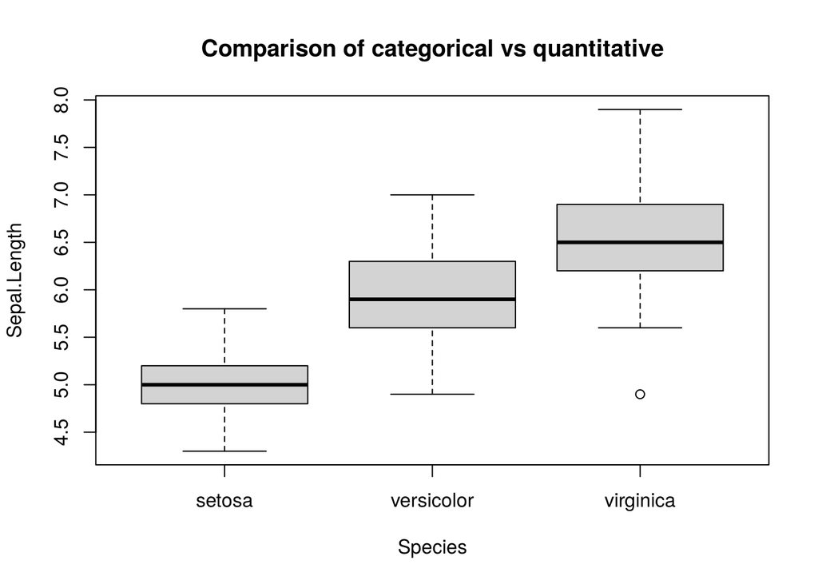

```r
boxplot(Sepal.Length ~ Species, data = iris,
        main = "Comparison of categorical vs quantitative")
```

### Two categorical variables and Simpson’s paradox

```r
ucba  <- data.frame(UCBAdmissions)
cross <- xtabs(Freq ~ Gender + Admit, data = ucba)
prop.table(cross, 1)          # overall: men admitted more
```

```
##         Admit
## Gender    Admitted  Rejected
##   Male   0.4451877 0.5548123
##   Female 0.3035422 0.6964578
```

```r
cross2 <- xtabs(Freq ~ Gender + Admit, data = ucba[ucba$Dept == "F", ])
prop.table(cross2, 1)         # in Dept F: women admitted more
```

```
##         Admit
## Gender     Admitted   Rejected
##   Male   0.05898123 0.94101877
##   Female 0.07038123 0.92961877
```

### Bar charts

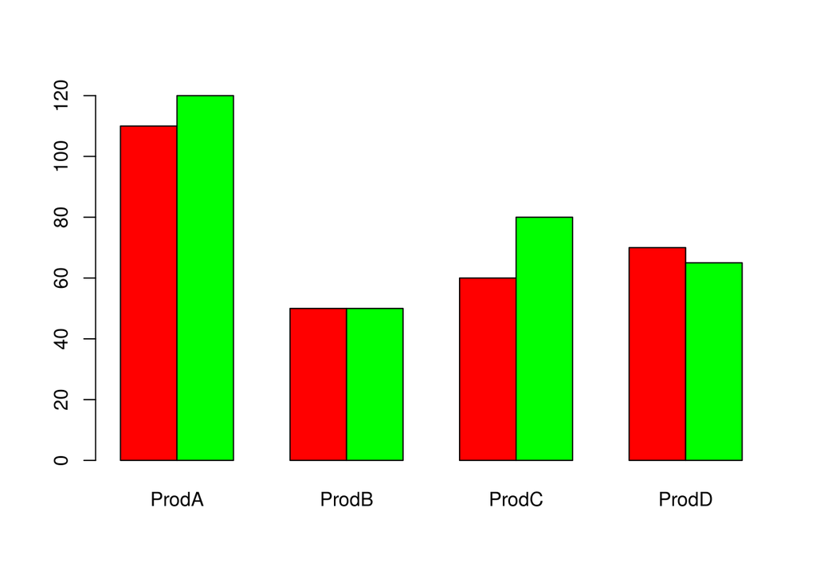

```r
dat <- read.table(text = "ProdA ProdB ProdC ProdD
1 110 50 60 70
2 120 50 80 65", header = TRUE)
barplot(as.matrix(dat), beside = TRUE, col = c("red", "green"))
```

### Scatter plot, correlation and linear model

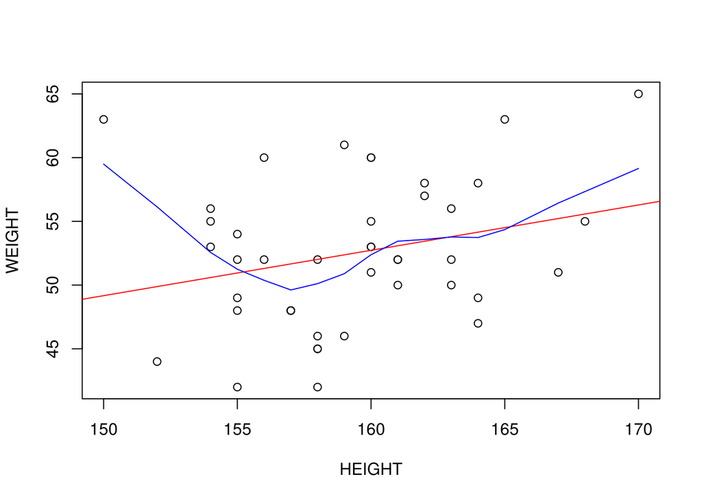

```r
plot(WEIGHT ~ HEIGHT, data = data_class)
abline(lm(WEIGHT ~ HEIGHT, data = data_class), col = "red")
lines(lowess(data_class$HEIGHT, data_class$WEIGHT), col = "blue")
```

```r
cor(data_class$HEIGHT, data_class$WEIGHT)
```

```
## [1] 0.2663495
```

```r
data_lm <- lm(HEIGHT ~ WEIGHT, data = data_class)
summary(data_lm)
```

```
##
## Call:
## lm(formula = HEIGHT ~ WEIGHT, data = data_class)
##
## Residuals:
##      Min       1Q   Median       3Q      Max
## -11.3563  -2.6662   0.2326   2.0378   8.2449
##
## Coefficients:
##             Estimate Std. Error t value Pr(>|t|)
## (Intercept) 148.7951     5.9466  25.022   <2e-16 ***
## WEIGHT        0.1994     0.1127   1.769   0.0843 .
## ---
## Signif. codes:  0 '***' 0.001 '**' 0.01 '*' 0.05 '.' 0.1 ' ' 1
##
## Residual standard error: 4.199 on 41 degrees of freedom
## Multiple R-squared:  0.07094,    Adjusted R-squared:  0.04828
## F-statistic: 3.131 on 1 and 41 DF,  p-value: 0.08427
```

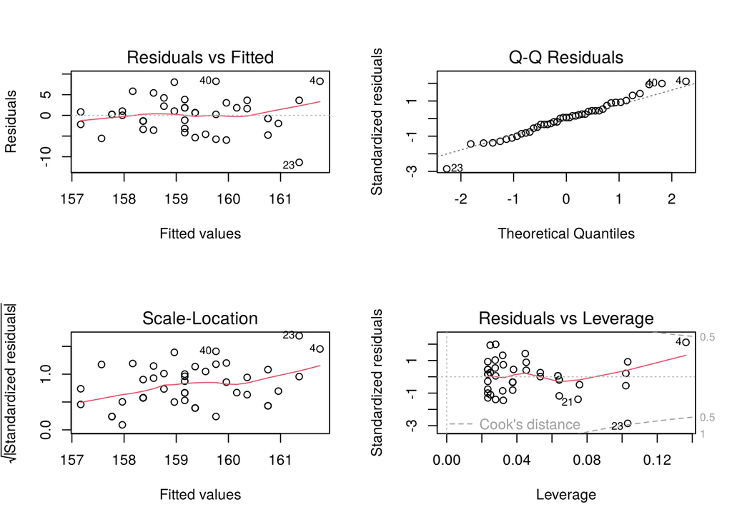

```r
par(mfrow = c(2, 2)); plot(data_lm); par(mfrow = c(1, 1))
```

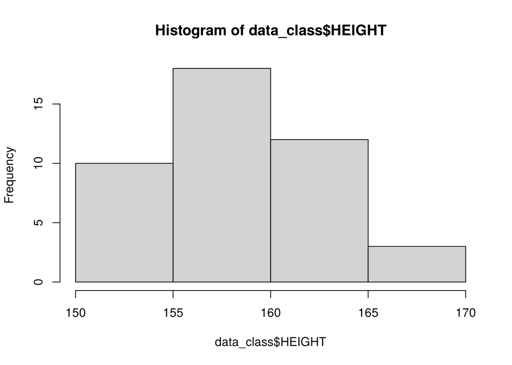

```r
hist(data_class$HEIGHT)
```

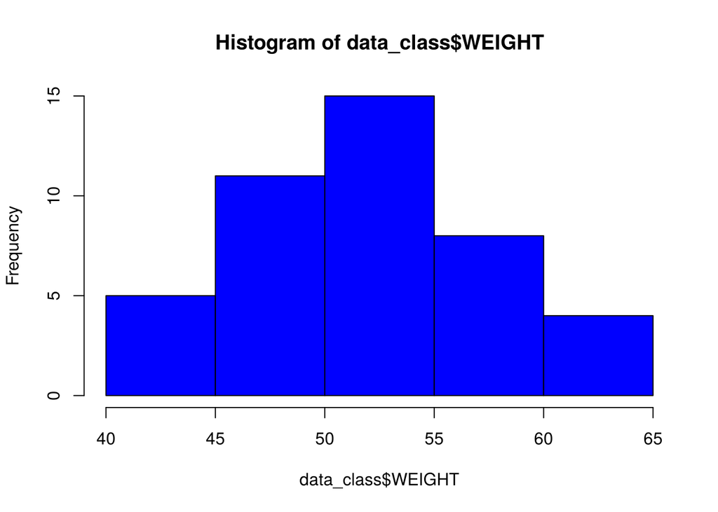

```r
hist(data_class$WEIGHT, col = "blue")
```

## 6. Data management

### New variable (BMI)

```r
data_class$BMI <- round(data_class$WEIGHT / (data_class$HEIGHT / 100)^2, 2)
head(data_class, 5)
```

```
##   HEIGHT WEIGHT   BMI
## 1    161     50 19.29
## 2    155     49 20.40
## 3    158     42 16.82
## 4    170     65 22.49
## 5    160     60 23.44
```

```r
summary(data_class$BMI)
```

```
##    Min. 1st Qu.  Median    Mean 3rd Qu.    Max.
##   16.82   19.16   20.40   20.70   22.23   28.00
```

```r
stem(data_class$BMI, scale = 2)
```

```
##
##   The decimal point is at the |
##
##   16 | 8
##   17 | 55
##   18 | 0022348
##   19 | 03555569
##   20 | 0114778
##   21 | 145667
##   22 | 1455
##   23 | 12446
##   24 | 17
##   25 |
##   26 |
##   27 |
##   28 | 0
```

### Dates

```r
today <- Sys.Date()
format(today, format = "%B %d %Y")
```

```
## [1] "October 31 2026"
```

```r
format(today, format = "%A")
```

```
## [1] "Saturday"
```

```r
difftime(today, as.Date("1982-02-10"), units = "days")
```

```
## Time difference of 16334 days
```

```r
as.Date("2011-01-22") - as.Date("2004-02-13")
```

```
## Time difference of 2535 days
```

### Leadership data: missing values, categories, sorting, subsetting

```r
manager <- c(1, 2, 3, 4, 5)
country <- c("US", "US", "UK", "UK", "UK")
gender  <- c("M", "F", "F", "M", "F")
age     <- c(32, 45, 25, 39, 99)
q1 <- c(5, 3, 3, 3, 2); q2 <- c(4, 5, 5, 3, 2); q3 <- c(5, 2, 5, 4, 1)
q4 <- c(5, 5, 5, NA, 2); q5 <- c(5, 5, 2, NA, 1)
leadership <- data.frame(manager, country, gender, age, q1, q2, q3, q4, q5)

leadership$age[leadership$age == 99] <- NA
leadership$agecat[leadership$age > 75] <- "Elder"
leadership$agecat[leadership$age >= 35 & leadership$age <= 75] <- "Middle Aged"
leadership$agecat[leadership$age < 35] <- "Young"
leadership
```

```
##   manager country gender age q1 q2 q3 q4 q5      agecat
## 1       1      US      M  32  5  4  5  5  5       Young
## 2       2      US      F  45  3  5  2  5  5 Middle Aged
## 3       3      UK      F  25  3  5  5  5  2       Young
## 4       4      UK      M  39  3  3  4 NA NA Middle Aged
## 5       5      UK      F  NA  2  2  1  2  1        <NA>
```

```r
na.omit(leadership)                          # listwise deletion
```

```
##   manager country gender age q1 q2 q3 q4 q5      agecat
## 1       1      US      M  32  5  4  5  5  5       Young
## 2       2      US      F  45  3  5  2  5  5 Middle Aged
## 3       3      UK      F  25  3  5  5  5  2       Young
```

```r
leadership[order(leadership$age), ]          # sorting
```

```
##   manager country gender age q1 q2 q3 q4 q5      agecat
## 3       3      UK      F  25  3  5  5  5  2       Young
## 1       1      US      M  32  5  4  5  5  5       Young
## 4       4      UK      M  39  3  3  4 NA NA Middle Aged
## 2       2      US      F  45  3  5  2  5  5 Middle Aged
## 5       5      UK      F  NA  2  2  1  2  1        <NA>
```

```r
leadership[c("q1", "q2", "q3", "q4", "q5")]  # select variables
```

```
##   q1 q2 q3 q4 q5
## 1  5  4  5  5  5
## 2  3  5  2  5  5
## 3  3  5  5  5  2
## 4  3  3  4 NA NA
## 5  2  2  1  2  1
```

```r
subset(leadership, age >= 35 | age < 24, select = c(q1, q2, q3, q4, q5))
```

```
##   q1 q2 q3 q4 q5
## 2  3  5  2  5  5
## 4  3  3  4 NA NA
```

```r
leadership[leadership$gender == "M" & leadership$age > 30 & !is.na(leadership$age), ]
```

```
##   manager country gender age q1 q2 q3 q4 q5      agecat
## 1       1      US      M  32  5  4  5  5  5       Young
## 4       4      UK      M  39  3  3  4 NA NA Middle Aged
```

### Merging

```r
extra <- data.frame(manager = 1:5, salary = c(5000, 6200, 4100, 5800, 7000))
merge(leadership, extra, by = "manager")      # horizontal
```

```
##   manager country gender age q1 q2 q3 q4 q5      agecat salary
## 1       1      US      M  32  5  4  5  5  5       Young   5000
## 2       2      US      F  45  3  5  2  5  5 Middle Aged   6200
## 3       3      UK      F  25  3  5  5  5  2       Young   4100
## 4       4      UK      M  39  3  3  4 NA NA Middle Aged   5800
## 5       5      UK      F  NA  2  2  1  2  1        <NA>   7000
```

```r
rbind(leadership[1:2, ], leadership[4, ])     # vertical
```

```
##   manager country gender age q1 q2 q3 q4 q5      agecat
## 1       1      US      M  32  5  4  5  5  5       Young
## 2       2      US      F  45  3  5  2  5  5 Middle Aged
## 4       4      UK      M  39  3  3  4 NA NA Middle Aged
```

# Part B: ggplot2 geom functions

Data: `singer` from the **lattice** package, as used in class. It has the height (in inches) of 235 singers in a choir, and their `voice.part` (Bass, Tenor, Alto, Soprano).

```r
library(ggplot2)
library(lattice)
data(singer)
str(singer)
```

```
## 'data.frame':    235 obs. of  2 variables:
##  $ height    : num  64 62 66 65 60 61 65 66 65 63 ...
##  $ voice.part: Factor w/ 8 levels "Bass 2","Bass 1",..: 8 8 8 8 8 8 8 8 8 8 ...
```

```r
summary(singer$height)
```

```
##    Min. 1st Qu.  Median    Mean 3rd Qu.    Max.
##    60.0    65.0    67.0    67.3    70.0    76.0
```

### geom_bar()

**Aim:** count how many singers are in each voice part. `geom_bar()` counts the rows for us.

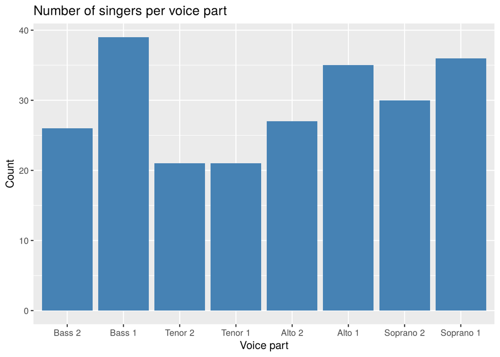

```r
ggplot(singer, aes(voice.part)) +
  geom_bar(fill = "steelblue") +
  labs(title = "Number of singers per voice part", x = "Voice part", y = "Count")
```

**What we see:** Bass 1 (39) and Soprano 1 (36) are the biggest groups. Tenor 1 and Tenor 2 are the smallest (21 each).

### geom_boxplot()

**Aim:** compare height between voice parts. A box plot shows the median, the middle 50% (the box) and outliers.

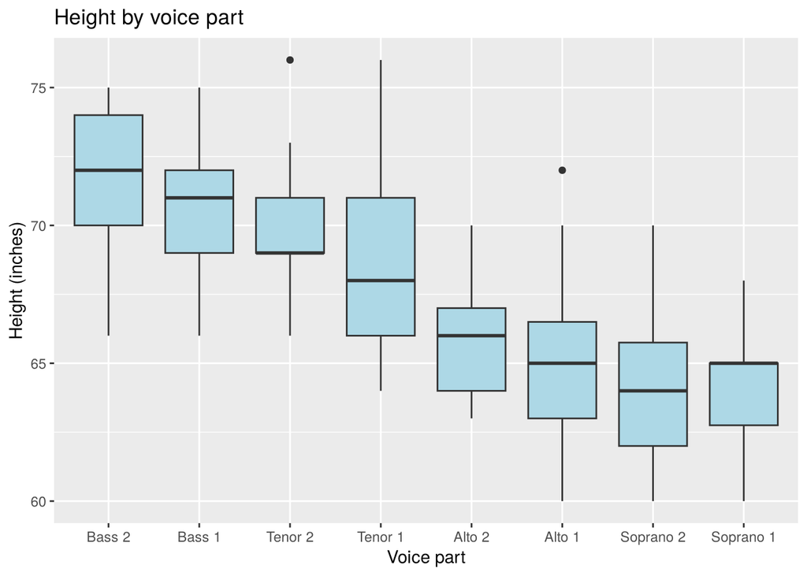

```r
ggplot(singer, aes(voice.part, height)) +
  geom_boxplot(fill = "lightblue") +
  labs(title = "Height by voice part", x = "Voice part", y = "Height (inches)")
```

**What we see:** height goes down from left to right. Bass 2 has the highest median (72 in), Soprano 2 the lowest (64 in). Lower voices belong to taller singers.

### geom_density()

**Aim:** show the shape of the height distribution as a smooth curve.

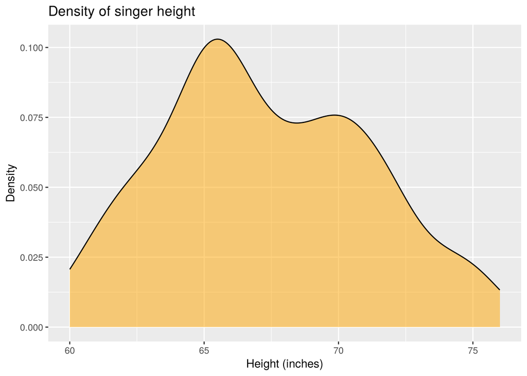

```r
ggplot(singer, aes(height)) +
  geom_density(fill = "orange", alpha = 0.5) +
  labs(title = "Density of singer height", x = "Height (inches)", y = "Density")
```

**What we see:** the curve has two bumps, near 65 and 70 inches. This suggests two groups mixed together (women in Alto/Soprano and men in Bass/Tenor).

### geom_histogram() with geom_vline() and geom_rug()

**Aim:** show how many singers fall in each height range. `geom_vline()` marks the mean, and `geom_rug()` puts a small tick for each singer under the x-axis.

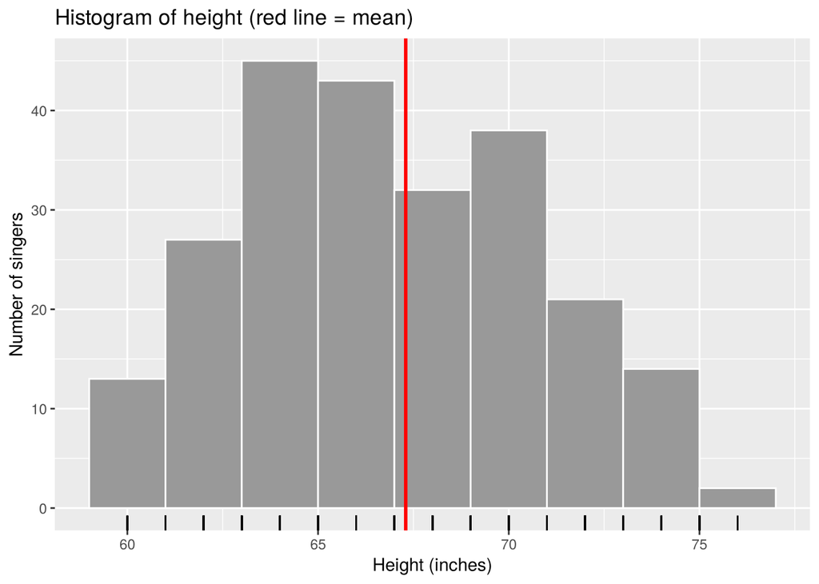

```r
ggplot(singer, aes(height)) +
  geom_histogram(binwidth = 2, fill = "grey60", colour = "white") +
  geom_vline(xintercept = mean(singer$height), colour = "red", linewidth = 1) +
  geom_rug() +
  labs(title = "Histogram of height (red line = mean)",
       x = "Height (inches)", y = "Number of singers")
```

**What we see:** heights go from 60 to 76 inches. The mean is 67.3 inches. Most singers are between 64 and 72 inches.

### geom_jitter() and geom_hline()

**Aim:** show every singer as a point. Many singers have the same height, so `geom_jitter()` moves points a little so they do not cover each other. `geom_hline()` draws the overall mean.

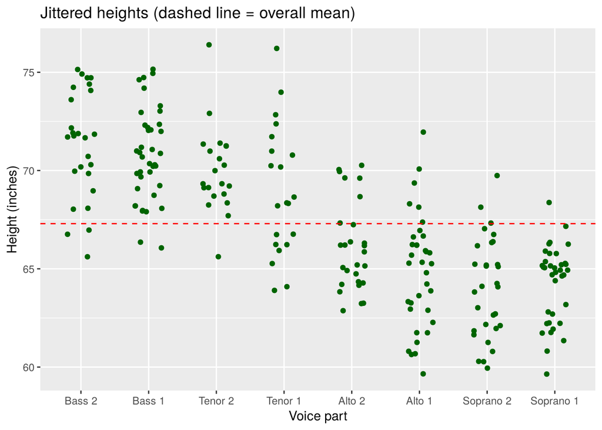

```r
ggplot(singer, aes(voice.part, height)) +
  geom_jitter(width = 0.2, colour = "darkgreen") +
  geom_hline(yintercept = mean(singer$height), linetype = "dashed", colour = "red") +
  labs(title = "Jittered heights (dashed line = overall mean)",
       x = "Voice part", y = "Height (inches)")
```

**What we see:** Bass and Tenor points are mostly above the mean line. Alto and Soprano points are mostly below it.

### geom_violin()

**Aim:** compare the full shape of height in each voice part. A wide part of the violin means many singers have that height. A small box plot inside shows the median.

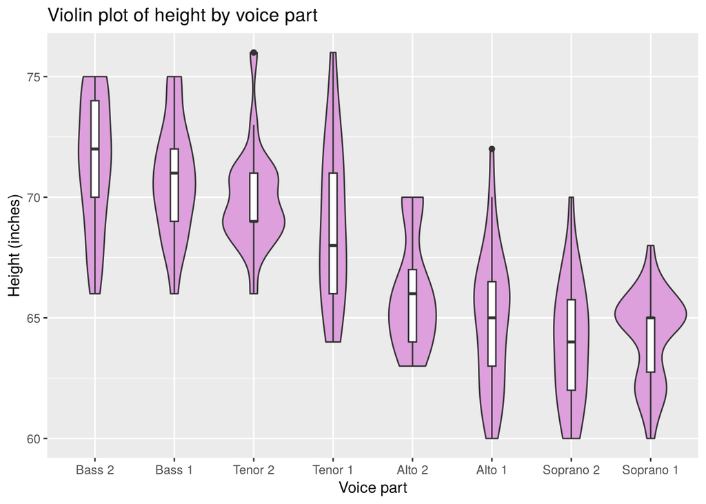

```r
ggplot(singer, aes(voice.part, height)) +
  geom_violin(fill = "plum") +
  geom_boxplot(width = 0.1) +
  labs(title = "Violin plot of height by voice part",
       x = "Voice part", y = "Height (inches)")
```

**What we see:** the same pattern as the box plot, but we also see where singers are most common. Tenor 1 and Alto 1 have the widest spread of heights (12 inches from shortest to tallest).

### geom_text()

**Aim:** put the exact value on top of each bar, so the reader does not need to guess.

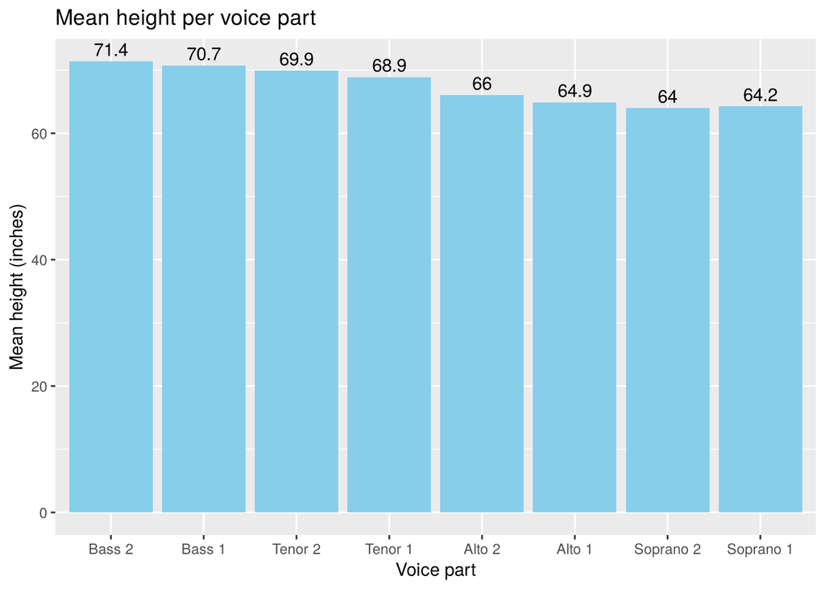

```r
means <- aggregate(height ~ voice.part, data = singer, FUN = mean)
ggplot(means, aes(voice.part, height)) +
  geom_col(fill = "skyblue") +
  geom_text(aes(label = round(height, 1)), vjust = -0.4) +
  labs(title = "Mean height per voice part", x = "Voice part", y = "Mean height (inches)")
```

**What we see:** mean height falls step by step from about 71 inches (Bass) to about 64 inches (Soprano).

### geom_line() and geom_point()

**Aim:** join the mean heights with a line to show the trend across voice parts. `geom_point()` marks each mean.

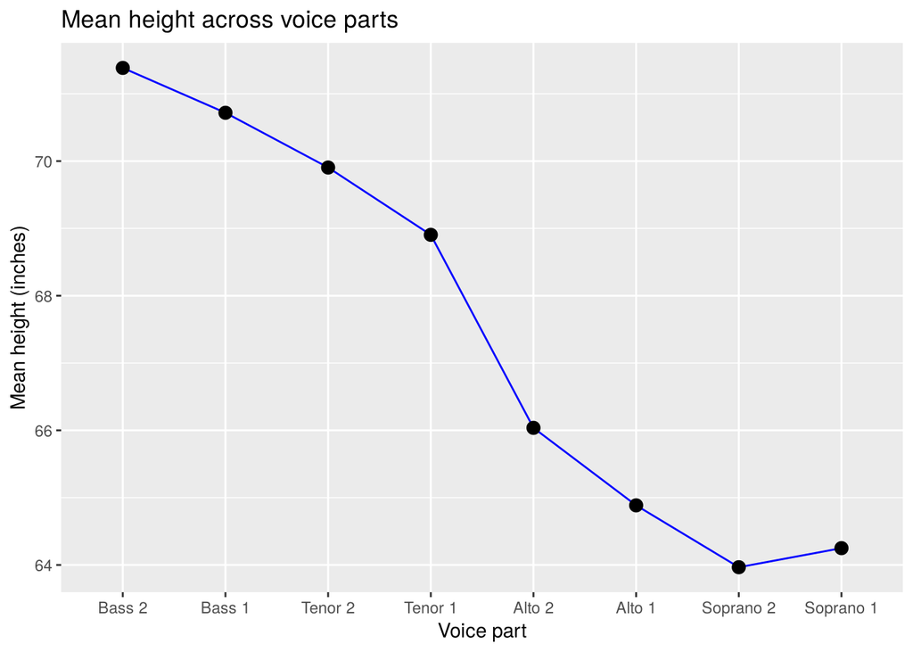

```r
ggplot(means, aes(voice.part, height, group = 1)) +
  geom_line(colour = "blue") +
  geom_point(size = 3) +
  labs(title = "Mean height across voice parts", x = "Voice part", y = "Mean height (inches)")
```

**What we see:** a clear downward trend. The biggest drop is between Tenor 1 and Alto 2, which is where the choir moves from male to female voices.

### geom_point() and geom_smooth()

**Aim:** check the relationship between two numeric variables. Here we use the class height and weight data. `geom_smooth(method = "lm")` adds a straight regression line with its confidence band.

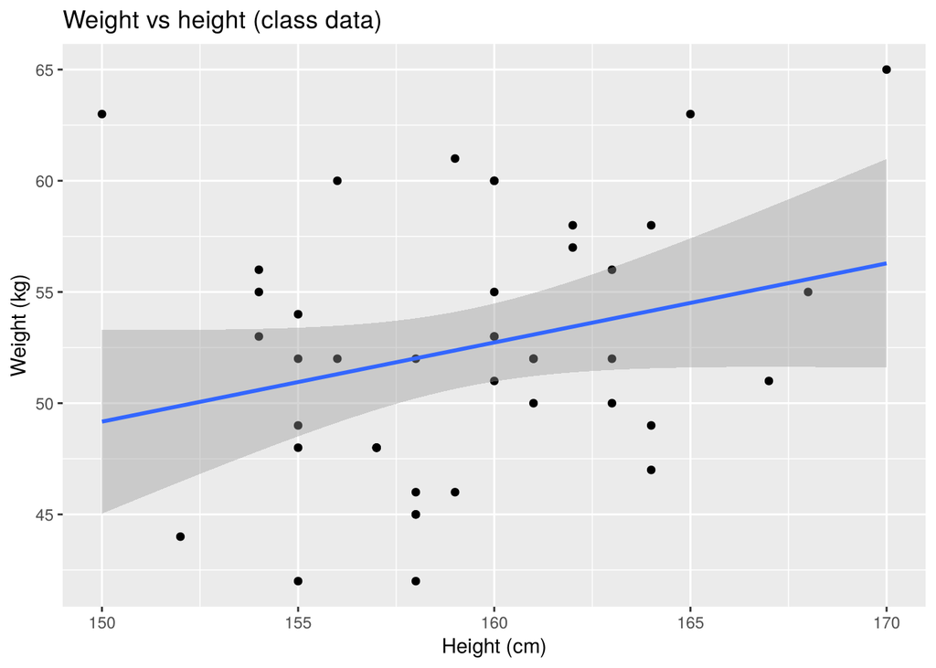

```r
ggplot(data_class, aes(HEIGHT, WEIGHT)) +
  geom_point() +
  geom_smooth(method = "lm") +
  labs(title = "Weight vs height (class data)", x = "Height (cm)", y = "Weight (kg)")
```

**What we see:** the line goes up a little, so taller students tend to be a bit heavier. But points are very spread out (r = 0.27), so the relationship is weak.

## Conclusion

- Taller singers sing lower parts (Bass, Tenor). Shorter singers sing higher parts (Alto, Soprano).
- The height distribution has two peaks, because the choir has both men and women.
- In the class data, height and weight have a weak positive relationship (r = 0.27).
- Each `geom_*()` function shows the data in a different way. Choosing the right one depends on the question we want to answer.